# SCEM Summative Section A

Averil Kan (ov21312)

12/11/2021

# Section A

Data wrangling task with some finance data.

## A.1

Load finance data and create data frame “finance_data_original”

```r
finance_data_original <- read.csv("./finance_data_EMATM0061.csv",fill=1)
dim(finance_data_original)
```

```
## [1] 1051   30
```

The data frame consist of 1051 rows and 30 columns

## A.2

Generate subset data frame “finance_data”

```r
finance_data <- finance_data_original %>%
  rename("education_expenditure"="Details.Education.Education.Total",
         "health_expenditure"="Details.Health.Health.Total.Expenditure",
         "transport_expenditure"="Details.Transportation.Highways.Highways.Total.Expenditure",
         "totals_revenue"="Totals.Revenue",
         "totals_expenditure"="Totals.Expenditure") %>%
  select(state_year_code,education_expenditure,health_expenditure,transport_expenditure,totals_revenue,totals_expenditure)

# Display subset of "finance_data" data frame consisting of the first five rows and first three columns
finance_data %>% select(state_year_code,education_expenditure,health_expenditure) %>%
  head(5)
```

```
##   state_year_code education_expenditure health_expenditure
## 1   ALABAMA__1992               3570524                 NA
## 2   ALABAMA__1993               3663465                 NA
## 3   ALABAMA__1994               3969277             487044
## 4   ALABAMA__1995               4400912             491648
## 5   ALABAMA__1996               4872259             514380
```

## A.3

Create a new column within “finance_data” data frame called “totals_saving”

```r
finance_data <- finance_data %>%
  mutate(totals_savings=totals_revenue-totals_expenditure)

# Display subset of "finance_data" data frame consisting of the first three rows and the four columns
finance_data %>% select(state_year_code, totals_revenue, totals_expenditure ,totals_savings) %>%
  head(3)
```

```
##   state_year_code totals_revenue totals_expenditure totals_savings
## 1   ALABAMA__1992       10536166            9650515         885651
## 2   ALABAMA__1993       11389335           10242374        1146961
## 3   ALABAMA__1994       11599362           10815221         784141
```

## A.4

Divide the “state_year_code” column into two separate columns, a “state” column and a “year” column

```r
finance_data <- finance_data %>%
  separate(state_year_code, into=c("state","year"), sep="__", convert=T) %>%
  mutate(state=str_to_title(state))

# Display subset of "finance_data" data frame consisting of the first three rows and the five columns
finance_data %>% select(state, year, totals_revenue, totals_expenditure, totals_savings) %>%
  head(3)
```

```
##     state year totals_revenue totals_expenditure totals_savings
## 1 Alabama 1992       10536166            9650515         885651
## 2 Alabama 1993       11389335           10242374        1146961
## 3 Alabama 1994       11599362           10815221         784141
```

## A.5

Generate a plot which displays the total revenue (“total_revenue”) as function of the year (“year”) for the following four states: Louisiana, Montana, Mississippi and Kentucky.

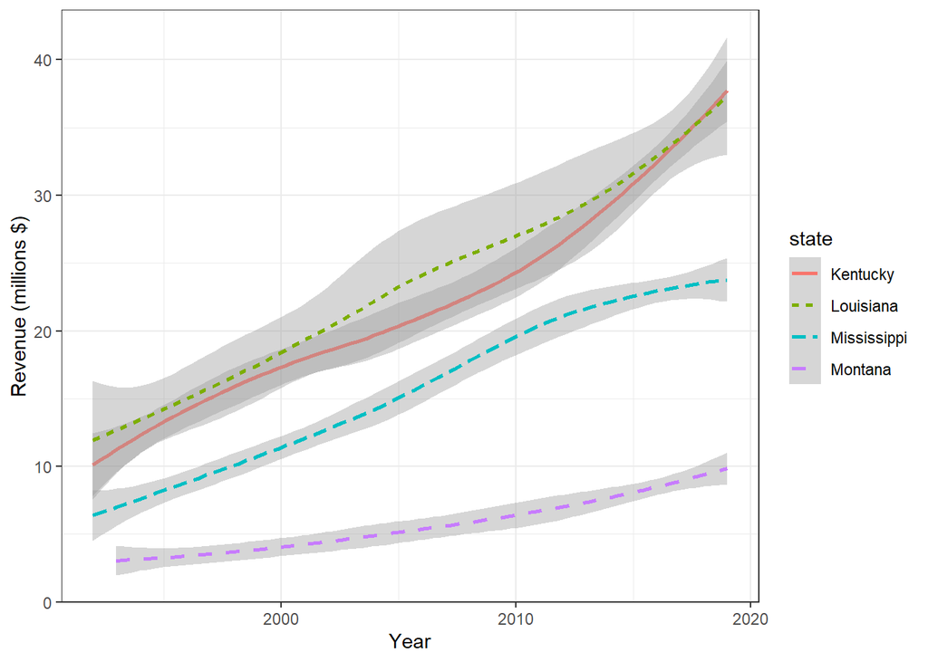

```r
finance_data %>%
  filter(state=="Louisiana"|state=="Montana"|state=="Mississippi"|state=="Kentucky") %>% #filters out the four states
  ggplot(aes(x=year,y=totals_revenue/1e+06))+
  geom_smooth(aes(color=state,linetype=state)) + #create geom smooth plot
  theme_bw()+
  labs(y="Revenue (millions $)", x="Year")
```

## A.6

Create a function called get_decade() which takes as input a number and rounds that number down to the nearest multiple of 10. For example, the numbers 20, 21, 22, . . . , 29 would all be mapped to the output 20.

Use your get_decade() function to add a new column to the “finance_data” data frame called “decade” which should give the decade corresponding to the year column. For example, the decade of the years 1990,1991,. . . ,1998,1999 is 1990.

```r
#Use modulus to extract rightmost digit and subtract from original year to floor year
get_decade <- function(x){
  return(x-x%%10)
}

finance_data <- finance_data %>%
  mutate(decade=map_dbl(.x=year,.f=~get_decade(.x)))

finance_data %>%
  group_by(state) %>%
  filter(decade==c(2000)) %>% #Chooses the decade starting 2000
  select(state, totals_savings) %>%
  summarise(across(where(is.numeric),~mean(.x,na.rm=T))) %>% #Calculate average savings across decade
  rename("mean_savings_across_decade"=totals_savings) %>%
  arrange(desc(mean_savings_across_decade)) %>% #Arrange in descending order
  head(3)
```

```
## # A tibble: 3 x 2
##   state      mean_savings_across_decade
##   <chr>                           <dbl>
## 1 Texas                        4103352.
## 2 Ohio                         3025980
## 3 California                   2510483.
```

Display of the top 3 total savings countries in descending order

## A.7

Next generate a summary data frame from the “finance_data” data frame called “alaska_summary”

```r
alaska_summary <- finance_data %>%
  group_by(decade) %>%
  filter((decade=="1990"|decade=="2000"|decade=="2010")&state=="Alaska") %>%
  select(decade,education_expenditure,health_expenditure,transport_expenditure) %>%
  summarise(across(ends_with(c("expenditure")), list(md=median,mn=mean), na.rm=T, .names="{substring(.col,1,2)}_{.fn}"))

# Display of "alaska_summary" data frame
alaska_summary
```

```
## # A tibble: 3 x 7
##   decade    ed_md    ed_mn   he_md   he_mn    tr_md    tr_mn
##    <dbl>    <dbl>    <dbl>   <dbl>   <dbl>    <dbl>    <dbl>
## 1   1990 1246864. 1246426. 164546. 162785.  582710.  582137.
## 2   2000 1566815  1546233. 160168  152003.  687407   723347.
## 3   2010 2595207  2642603. 278394  274688  1271514  1210822.
```

## A.8

Create a function called impute_by_median which takes as input a vector numerical values, which may include some “NA”s, and replaces any missing values (“NA”s) with the median over the vector.

```r
impute_by_median <- function(x){
  med<-median(x,na.rm=1)
  impute_f <- function(y){
    if(is.na(y)){
      return(med)
    }else{
      return(y)
    }
  }
  return(map_dbl(x,impute_f))
}
```

Generate a subset of your “finance_data” data frame called “idaho_2000”

```r
idaho_2000 <- finance_data %>%
  filter(decade==c(2000),state==c("Idaho")) %>%
  select(-state,-decade)
idaho_2000
```

```
##   year education_expenditure health_expenditure transport_expenditure
## 1 2000               1663980              98510                470498
## 2 2001               1768837             103705                501659
## 3 2002                    NA                 NA                499916
## 4 2003               1886421             116088                521746
## 5 2004                    NA             131165                524242
##   totals_revenue totals_expenditure totals_savings
## 1        5576284            4492552        1083732
## 2        5286097            4951659         334438
## 3        4487672            5234047        -746375
## 4        5492993                 NA             NA
## 5        7112364            5762624        1349740
```

Apply “impute_by_median” function to create a new data frame called “idaho_2000_imputed”

```r
idaho_2000_imputed <- idaho_2000 %>%
  mutate(education_expenditure=impute_by_median(education_expenditure),
         health_expenditure=impute_by_median(health_expenditure),
         transport_expenditure=impute_by_median(transport_expenditure),
         totals_revenue=impute_by_median(totals_revenue),
         totals_expenditure=impute_by_median(totals_expenditure),
         totals_savings=impute_by_median(totals_savings))

# Display subset of "idaho_2000_imputed" data frame consisting of the first five rows and the four columns
idaho_2000_imputed %>%
  select(year,health_expenditure,education_expenditure,totals_savings) %>%
  head(5)
```

```
##   year health_expenditure education_expenditure totals_savings
## 1 2000            98510.0               1663980        1083732
## 2 2001           103705.0               1768837         334438
## 3 2002           109896.5               1768837        -746375
## 4 2003           116088.0               1886421         709085
## 5 2004           131165.0               1768837        1349740
```